# Explore your data

Import, cleaning, exploration, transformation

Dr. Peng Zhao

## Ice breaking

> We are extremely fortunate not to know precisely the kind of world we live in.

> — W. Szymborska

> 我们何其幸运，无法确知自己生活在什么样的世界。

[figure not shown]

> We are extremely fortunate not to know precisely the kind of data we deal with.

> — Me, DPH206

## Objectives

1. Understand the procedure of data exploration.
2. Learn the R functions in data exploration.
3. Use R to explore data in Environmental Science and/or Public Health.

## Import data

### Character separated data

Comma separated data (.csv) is the most recommended data format, because it is

1. widely supported,
2. small,
3. independent,
4. stable, and
5. sufficient for use in most cases.

```r
read.csv()
read.table(sep = ",")
readr::read_csv()
```

Tab separated data is an alternative to .csv. Besides the advantages of .csv, tab separated data is friendly to human’s eyes.

Download a demo dataset: https://pzhao.org/data/death_rate_tab.txt

```r
read.delim()
read.table(sep = "\t")
readr::read_delim(delim = "\t")
```

Sometimes, your data might be separated by other characters.

Download a demo dataset: https://pzhao.org/data/death_rate_semicolon.txt

```r
read.table(sep = ';')
```

### Excel file

Can R directly read Excel files? If so, how?

Search online.

For reading Excel file (.xlsx, .xls), you can use the package “readxl”.

Download a demo dataset: https://pzhao.org/data/birdflu.xls

```r
library("readxl")
bf <- read_excel("birdflu.xls")
bf_deaths <- read_excel("birdflu.xls", sheet = "death")
```

Another package, “xlsx” is more powerful, which can not only read from, but also write to Excel file.

Before using “xlsx”, java must be downloaded. Choose the right version[^1] from the [download link](https://www.java.com/en/download/manual.jsp).

```r
library(xlsx)
bf <- read.xlsx("birdflu.xls", sheetName = 'case')
write.xlsx(cars, "birdflu.xls", sheetName = "my test", append = TRUE)
```

### From R packages

The “WHO” package.

```r
install.packages("remotes")
remotes::install_github("expersso/WHO")
help(package = "WHO")
require(WHO)
codes <- get_codes()
whod <- get_data("MDG_0000000007")
```

The “nCov2019” package.

```r
remotes::install_github("GuangchuangYu/nCov2019")
library(nCov2019)
ncovr_data <- load_nCov2019()
```

Exercises:

1. How do you import the following files into R or into your favorite tools?
- https://pzhao.org/data/rworkshop1.RDS
- https://pzhao.org/data/cm.zip
2. Can you find another R package for COVID-19 data? How does it work?

Poll: [Where are you from?](https://www.mentimeter.com/s/fc1e12fb7fb98dc692d408b6c82b7b0c/22d9bb9570d3)

## Overview data

The first step in analyzing data:

1. Where are the data centred? How are they spread? Are they symmetric, skewed, bimodal?
2. Are there outliers?
3. Are the variables normally distributed?
4. Are there any relationships between the variables? Are relationships between the variables linear? Which follow-up analysis should be applied?
5. Do we need a transformation?
6. Was the sampling effort approximately the same for each observation or variable?

Demo data: https://pzhao.org/data/diamonds2.zip

Meta data: originated from the data `diamonds` in the **ggplot2** or *tidyverse* package.

```r
diamonds2 <- read.csv("diamonds2.csv")
```

```r
library(tidyverse)
help("diamonds")
```

View the data visually (filter and search):

```r
View(diamonds2)
```

Data structure:

```r
str(diamonds2)
dim(diamonds2)
```

Summary:

```r
summary(diamonds2)
```

## Clean data

### Data type

```r
diamonds2$x <- as.numeric(diamonds2$x)

unique(diamonds2$cut)
```

```
## [1] "Ideal"     "Premium"   "Good"      "Very Good" "Fair"      "Fare"
```

```r
diamonds2$cut[diamonds2$cut == "Fare"] <- "Fair"
diamonds2$cut <- as.factor(diamonds2$cut)

unique(diamonds2$color)
```

```
## [1] "E" "I" "J" "H" "F" "G" "D" "h"
```

```r
diamonds2$color[diamonds2$color == "h"] <- "H"
diamonds2$color <- as.factor(diamonds2$color)
```

```r
str(diamonds2)
summary(diamonds2)
```

### Impossible values

```r
diamonds2$carat[diamonds2$carat < 0] <- NA
diamonds2$x[diamonds2$x == 999] <- NA
summary(diamonds2)
```

```
##      carat              cut        color       clarity              depth
##  Min.   :0.200   Fair     : 1705   D: 6763   Length:53940       Min.   :43.00
##  1st Qu.:0.400   Good     : 4896   E: 9782   Class :character   1st Qu.:61.00
##  Median :0.700   Ideal    :21509   F: 9523   Mode  :character   Median :61.80
##  Mean   :0.798   Premium  :13767   G:11270                      Mean   :61.75
##  3rd Qu.:1.040   Very Good:12063   H: 8388                      3rd Qu.:62.50
##  Max.   :5.010                     I: 5411                      Max.   :79.00
##  NA's   :100                       J: 2803
##      table           price             x                y
##  Min.   :43.00   Min.   :  326   Min.   : 0.000   Min.   : 0.000
##  1st Qu.:56.00   1st Qu.:  950   1st Qu.: 4.710   1st Qu.: 4.720
##  Median :57.00   Median : 2401   Median : 5.700   Median : 5.710
##  Mean   :57.46   Mean   : 3933   Mean   : 5.731   Mean   : 5.735
##  3rd Qu.:59.00   3rd Qu.: 5324   3rd Qu.: 6.540   3rd Qu.: 6.540
##  Max.   :95.00   Max.   :18823   Max.   :10.740   Max.   :58.900
##                                  NA's   :100
##        z
##  Min.   : 0.000
##  1st Qu.: 2.910
##  Median : 3.530
##  Mean   : 3.539
##  3rd Qu.: 4.040
##  Max.   :31.800
##
```

Exercise:

- Download a dataset https://pzhao.org/data/clean.txt.
- Import it into R.
- Clean it.

## Explore data

### One dimensional data

#### Dotplot

A dotplot displays the original data.

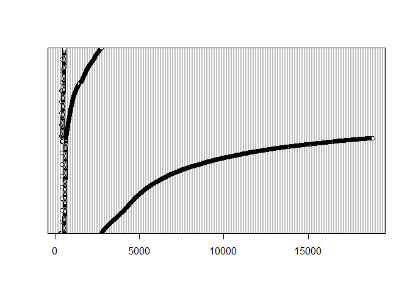

```r
dotchart(diamonds2$price)
```

```
## [1] "1/10 carat"
```

```
## [1] "2/10 cut"
```

```
## [1] "3/10 color"
```

```
## [1] "4/10 clarity"
```

```
## [1] "5/10 depth"
```

```
## [1] "6/10 table"
```

```
## [1] "7/10 price"
```

```
## [1] "8/10 x"
```

```
## [1] "9/10 y"
```

```
## [1] "10/10 z"
```

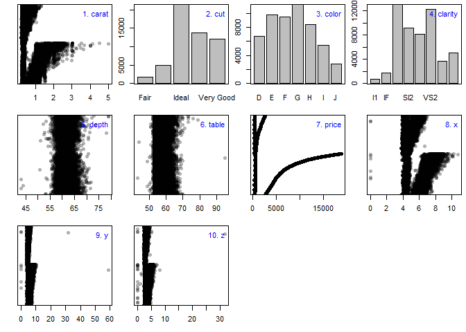

```r
beginr::plot_summary(diamonds2)
```

#### Histogram

A histogram shows the distribution of the data and gives an indication of normality.

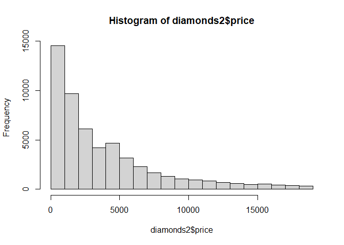

```r
library(tidyverse)
hist(diamonds2$price)
```

```
## [1] "1/10 carat"
```

```
## [1] "2/10 cut"
```

```
## [1] "3/10 color"
```

```
## [1] "4/10 clarity"
```

```
## [1] "5/10 depth"
```

```
## [1] "6/10 table"
```

```
## [1] "7/10 price"
```

```
## [1] "8/10 x"
```

```
## [1] "9/10 y"
```

```
## [1] "10/10 z"
```

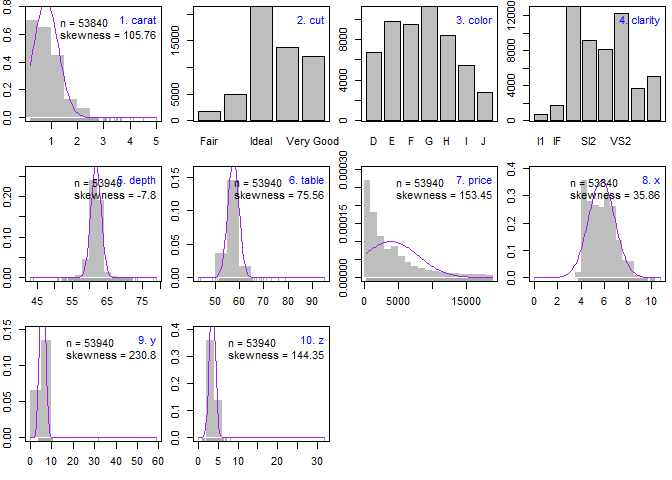

```r
beginr::plot_summary(diamonds2, base = "hist")
```

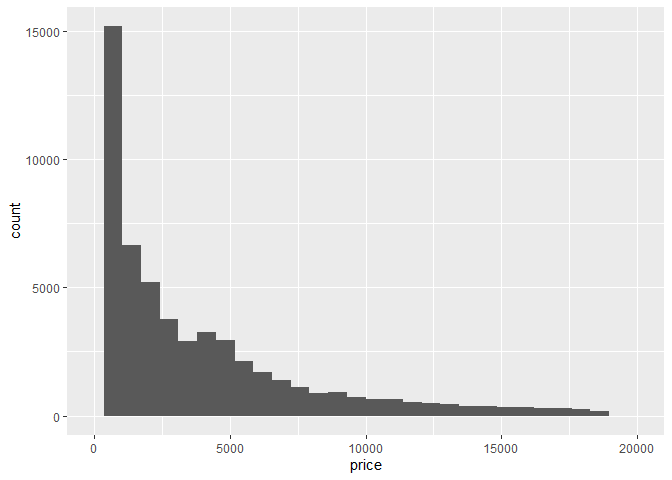

```r
p_hist <-
  diamonds2 %>%
  ggplot() +
  geom_histogram(aes(price)) +
  xlim(0, 20000)

p_hist
```

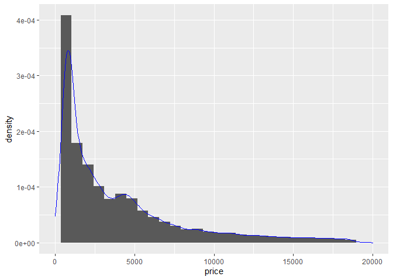

```r
p_hist2 <-
  diamonds2 %>%
  ggplot() +
  geom_histogram(aes(price, after_stat(density))) +
  xlim(0, 20000)


p_density <-
  p_hist2 + geom_density(aes(price), color = "blue")

p_density
```

#### Boxplot

A boxplot checks the center, the spread and outliers in a non-parametric way.

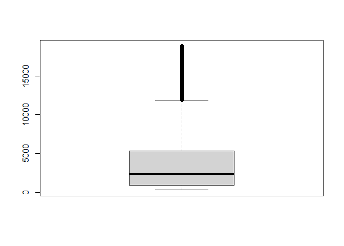

```r
boxplot(diamonds2$price)
```

```
## [1] "1/10 carat"
```

```
## [1] "2/10 cut"
```

```
## [1] "3/10 color"
```

```
## [1] "4/10 clarity"
```

```
## [1] "5/10 depth"
```

```
## [1] "6/10 table"
```

```
## [1] "7/10 price"
```

```
## [1] "8/10 x"
```

```
## [1] "9/10 y"
```

```
## [1] "10/10 z"
```

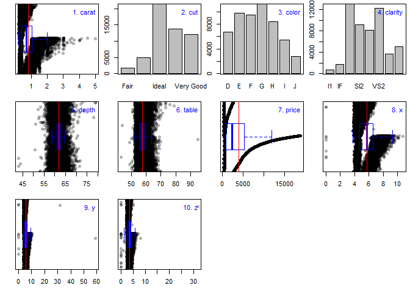

```r
beginr::plot_summary(diamonds2, if_box = TRUE)
```

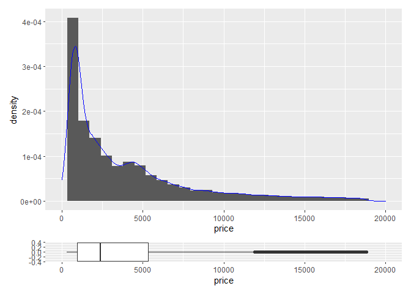

```r
p_box <-
  diamonds2 %>%
  ggplot() +
  geom_boxplot(aes(price)) +
  xlim(0, 20000)

library(patchwork)
p_density / p_box + plot_layout(heights = c(10, 1))
```

Conditional:

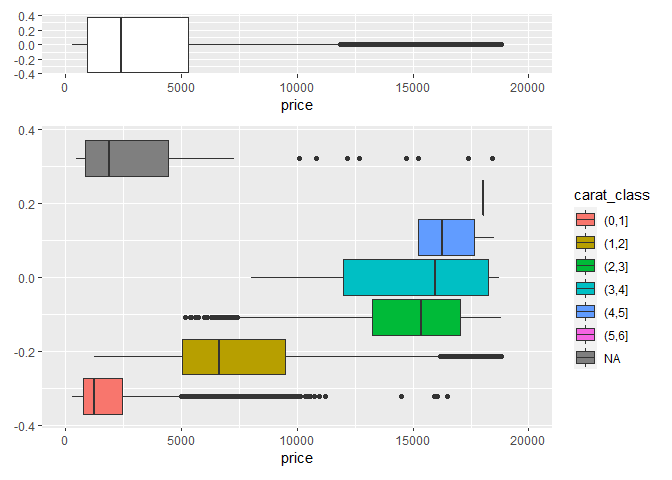

```r
diamonds2$carat_class <- cut(diamonds2$carat, 0:6)
p_box2 <- diamonds2 %>%
  ggplot() +
  geom_boxplot(aes(price, fill = carat_class)) +
  xlim(0, 20000)
p_box / p_box2 + plot_layout(heights  = c(1, 5))
```

#### QQ plot

A Quantile-Quantile plot determines whether the data follow a particular distribution.

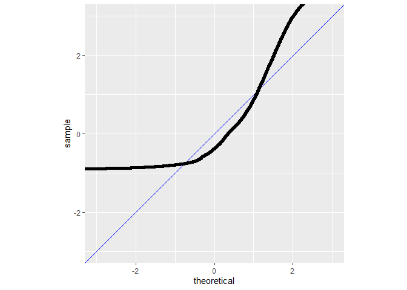

```r
library(qqplotr)

diamonds2 %>%
  ggplot() +
  geom_abline(aes(intercept = 0, slope = 1), color = "blue") +
  coord_fixed(ratio = 1, xlim = c(-3, 3), ylim = c(-3,3)) +
  stat_qq_point(aes(sample = scale(price)))
```

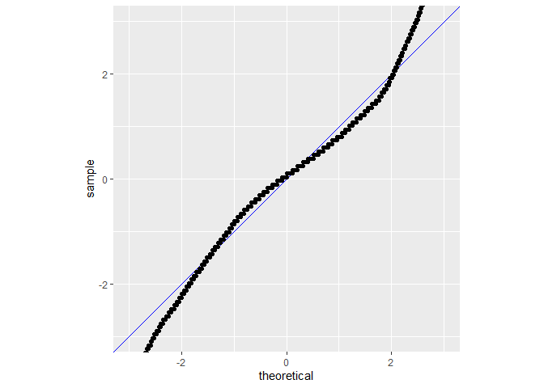

```r
diamonds2 %>%
  ggplot() +
  geom_abline(aes(intercept = 0, slope = 1), color = "blue") +
  coord_fixed(ratio = 1, xlim = c(-3, 3), ylim = c(-3,3)) +
  stat_qq_point(aes(sample = scale(depth)))
```

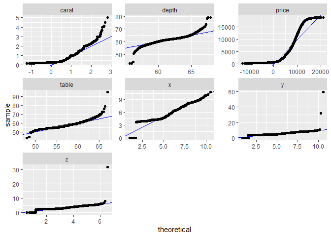

```r
diamonds2[, -c(2:4, 11)] %>%
  gather() %>%
  ggplot() +
  geom_abline(aes(intercept = 0, slope = 1), color = "blue") +
  facet_wrap(~key, scales = "free") +
  stat_qq_point(aes(sample = value))
```

### Two dimensional data

#### Scatterplot

A scatterplot explores a relationship between two variables.

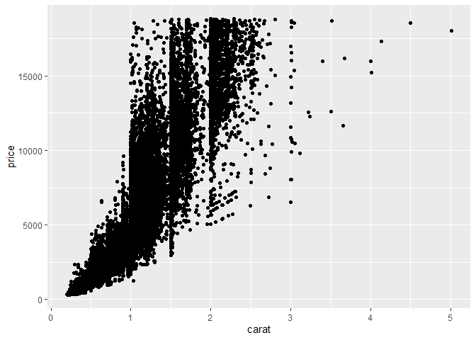

```r
diamonds2 %>%
  ggplot() +
  geom_point(aes(carat, price))
```

#### Pairplot

A pairplot explores relationships between every two variables.

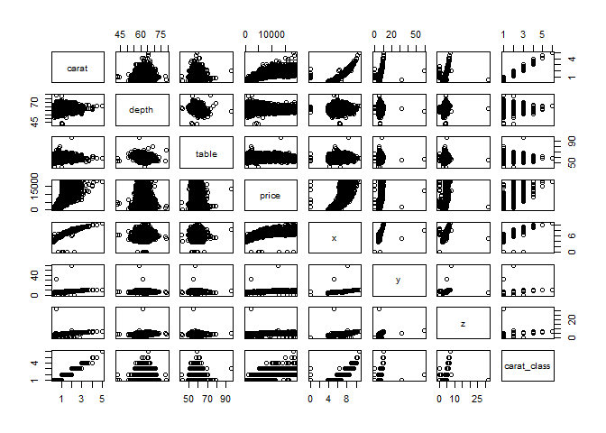

```r
pairs(diamonds2[, -(2:4)])
```

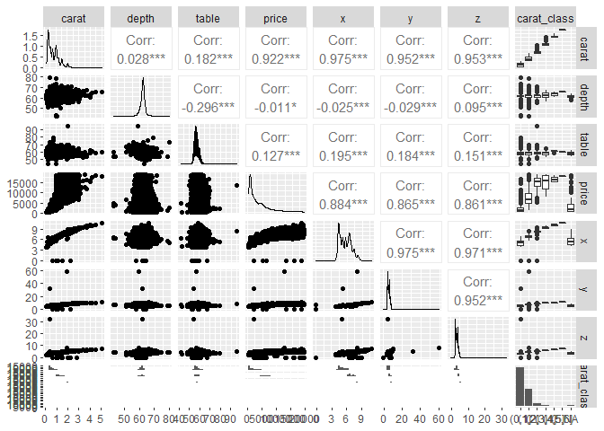

```r
library(GGally)
diamonds2[, -(2:4)] %>%
  ggpairs()
```

#### Coplot

A coplot explores the relationship between two variables for different values of a third variable.

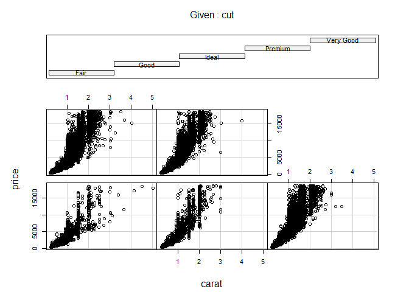

[output not shown]

```r
coplot(price ~ carat|cut, data = diamonds2)
```

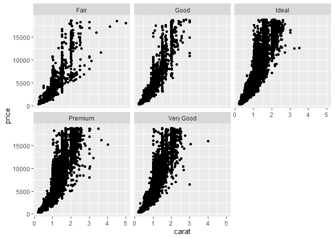

```r
diamonds2 %>%
  ggplot(aes(carat, price)) +
  geom_point() +
  facet_wrap(~cut)
```

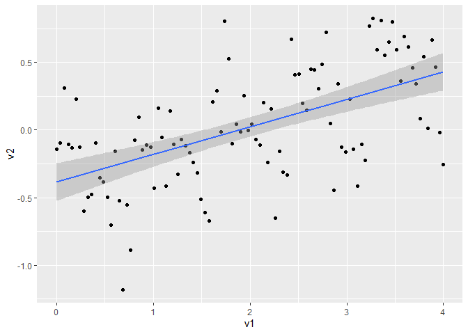

```r
set.seed(123)
v1 <- seq(0, 4, length = 100)
v3 <- rep(0:4, each = 20)
v2 <- - v1 + v3 + rnorm(100, 0, .25)
x <- data.frame(v1, v2, v3)
x %>%
  ggplot(aes(v1, v2)) +
  geom_point() +
  geom_smooth(method = "lm")
```

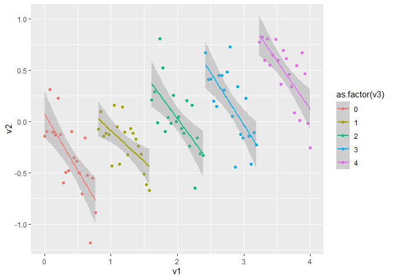

```r
x %>%
  ggplot(aes(v1, v2, color = as.factor(v3))) +
  geom_point() +
  geom_smooth(method = "lm")
```

## Outlier

An outlier is a data point with an extreme value compared to the rest of the dataset. It might incorrectly influence an analysis. It might be a hint for a great discovery.

[figure not shown]

An example for research of outliers: Peppa Pig

Step 1. Observation: Elephant Edmond and Emily. And Peppa Pig.

Step 2. Curiosity:

- The names of Edmond and Emily begin with *E*, the initial of the spelling of *elephant*.
- The names of Peppa begins with *P*, the initial of the spelling of *pig*.

Step 3. Hypothesis: The initial letter of any character’ name in Peppa Pig is the same as the spelling of the animal.

Step 4. Collect and explore data:

| Character | Animal |
| --- | --- |
| Edmond | elephant |
| Susie | sheep |
| Candy | cat |
| Danny | dog |
| Pedro | pony |
| Zoe | zebra |
| Rebecca | rabbit |
| Freddy | fox |
| Delphine | donkey |
| Wendy | wolf |

[figure not shown]

Step 5. Outlier: George Pig

- Assumption: there must a word which begins with *g* and means *pig*.
- Analysis: Look up the dictionary for the thesaurus for *pig*.

Step 6. Conclusion.

Exercise:

- What step is missing in the workflow of this research on Peppa pig?
- If you write an article on this research, how do your organize the structure of your article?

## Transformation

Data transformation is often needed for finding the relationship between two variables.

Based on theory:

https://pzhao.org/data/speed.csv

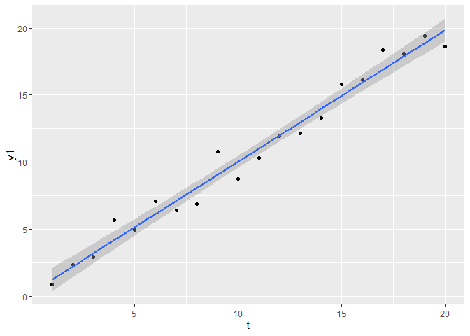

```r
speed <- read.csv("speed.csv")
speed %>%
  ggplot(aes(t, y1)) +
  geom_point() +
  geom_smooth(method = "lm")
```

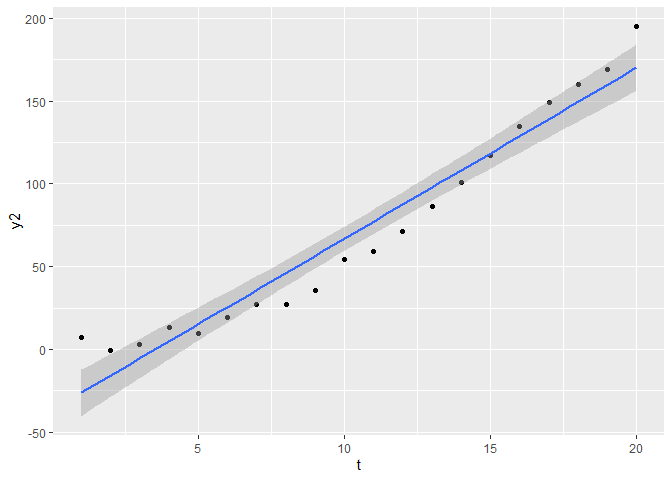

```r
speed %>%
  ggplot(aes(t, y2)) +
  geom_point() +
  geom_smooth(method = "lm")
```

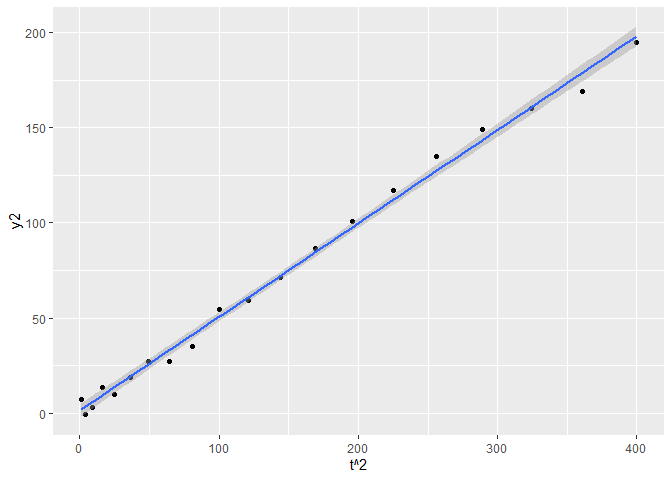

```r
speed %>%
  ggplot(aes(t^2, y2)) +
  geom_point() +
  geom_smooth(method = "lm")
```

Based on experience:

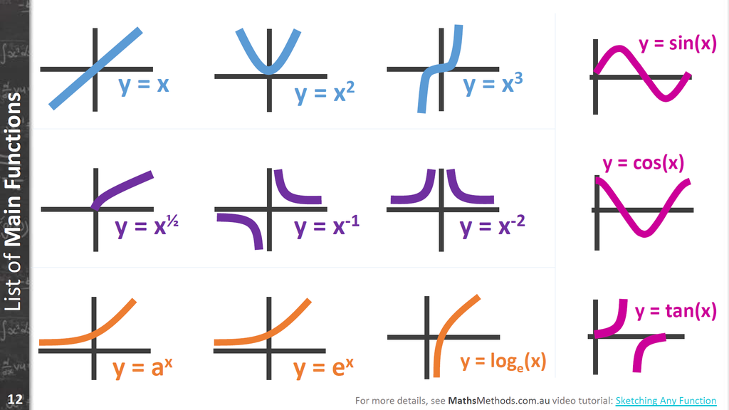

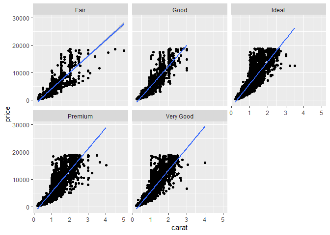

```r
diamonds2 %>%
  ggplot(aes(carat, price)) +
  geom_point() +
  # scale_y_log10() +
  # scale_x_log10() +
  facet_wrap(~cut) +
  geom_smooth(method = "lm")
```

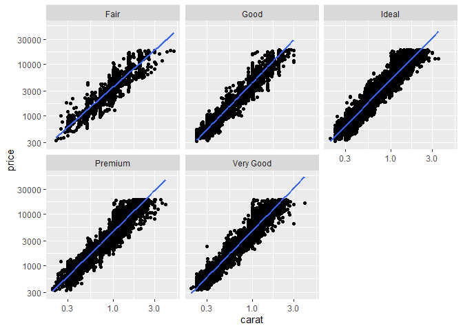

```r
diamonds2 %>%
  ggplot(aes(carat, price)) +
  geom_point() +
  scale_y_log10() +
  scale_x_log10() +
  facet_wrap(~cut) +
  geom_smooth(method = "lm")
```

## What Next?

- The data exploration might be correct. Study further and dig more out.
- The data exploration might be wrong. Study further and prove it.
- Anyway, data exploration is a starting point for your data analysis.

Exercises:

- Sometimes you have to standarize the data for further analysis. What is data standarization? Give an example.
- Sometimes you have to scale the data. What is scaling data? Give an example.
- Explore the data “airquality”.
[^1]: 32 bit or 64 bit. If you choose a wrong one, you cannot properly load the “xlsx” package.